# credit-risk-modeling

## Statement of Completion

[figure not shown]

```python
# Import library
import pandas as pd
import matplotlib.pyplot as plt
```

```python
# Read in data
cr_loan = pd.read_csv('./data/cr_loan.csv')
```

# Exploring and Preparing Loan Data

### 1.1. Explore credit data

Begin by looking at the data set `cr_loan`. In this data set, `loan_status` shows whether the loan is currently in default with 1 being default and 0 being non-default.

You have more columns within the data, and many could have a relationship with the values in `loan_status`. You need to explore the data and these relationships more with further analysis to understand the impact of the data on credit loan defaults.

Checking the structure of the data as well as seeing a snapshot helps us better understand what's inside the set. Similarly, visualizations provide a high level view of the data in addition to important trends and patterns.

```python
# Check the structure of the data
print(cr_loan.dtypes)

# Check the first five rows of the data
cr_loan.head()
```

```
person_age                      int64
person_income                   int64
person_home_ownership          object
person_emp_length             float64
loan_intent                    object
loan_grade                     object
loan_amnt                       int64
loan_int_rate                 float64
loan_status                     int64
loan_percent_income           float64
cb_person_default_on_file      object
cb_person_cred_hist_length      int64
dtype: object
```

|  | person_age | person_income | person_home_ownership | person_emp_length | loan_intent | loan_grade | loan_amnt | loan_int_rate | loan_status | loan_percent_income | cb_person_default_on_file | cb_person_cred_hist_length |
| --- | --- | --- | --- | --- | --- | --- | --- | --- | --- | --- | --- | --- |
| 0 | 22 | 59000 | RENT | 123.0 | PERSONAL | D | 35000 | 16.02 | 1 | 0.59 | Y | 3 |
| 1 | 21 | 9600 | OWN | 5.0 | EDUCATION | B | 1000 | 11.14 | 0 | 0.10 | N | 2 |
| 2 | 25 | 9600 | MORTGAGE | 1.0 | MEDICAL | C | 5500 | 12.87 | 1 | 0.57 | N | 3 |
| 3 | 23 | 65500 | RENT | 4.0 | MEDICAL | C | 35000 | 15.23 | 1 | 0.53 | N | 2 |
| 4 | 24 | 54400 | RENT | 8.0 | MEDICAL | C | 35000 | 14.27 | 1 | 0.55 | Y | 4 |

```python
print('Number of samples = {}'.format(cr_loan.shape[0]))
print("Features:\n\t",list(cr_loan.columns))
```

```
Number of samples = 32581
Features:
	 ['person_age', 'person_income', 'person_home_ownership', 'person_emp_length', 'loan_intent', 'loan_grade', 'loan_amnt', 'loan_int_rate', 'loan_status', 'loan_percent_income', 'cb_person_default_on_file', 'cb_person_cred_hist_length']
```

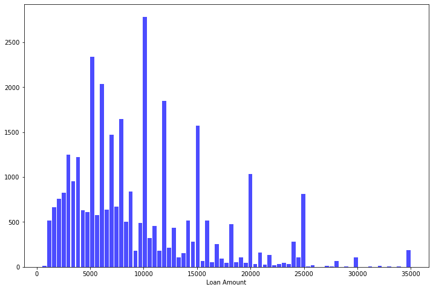

```python
# Look at the distribution of loan amounts with a histogram
fig = plt.figure(figsize=(12,8))
plt.hist(x=cr_loan['loan_amnt'], bins='auto', color='blue',alpha=0.7, rwidth=0.85)
plt.xlabel("Loan Amount")
plt.show()
```

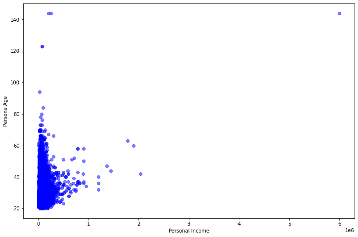

```python
# Plot a scatter plot of income against age
fig = plt.figure(figsize=(12,8))
plt.scatter(cr_loan['person_income'], cr_loan['person_age'],c='blue', alpha=0.5)
plt.xlabel('Personal Income')
plt.ylabel('Persone Age')
plt.show()
```

## 1.2. Crosstab and pivot tables

Often, financial data is viewed as a pivot table in spreadsheets like Excel.

With cross tables, you get a high level view of selected columns and even aggregation like a count or average. For most credit risk models, especially for probability of default, columns like `person_emp_length` and `person_home_ownership` are common to begin investigating.

You will be able to see how the values are populated throughout the data, and visualize them. For now, you need to check how `loan_status` is affected by factors like home ownership status, loan grade, and loan percentage of income.

```python
# Create a cross table of the loan intent and loan status
pd.crosstab(cr_loan['loan_intent'], cr_loan['loan_status'], margins = True)
```

| loan_status loan_intent | 0 | 1 | All |
| --- | --- | --- | --- |
| DEBTCONSOLIDATION | 3722 | 1490 | 5212 |
| EDUCATION | 5342 | 1111 | 6453 |
| HOMEIMPROVEMENT | 2664 | 941 | 3605 |
| MEDICAL | 4450 | 1621 | 6071 |
| PERSONAL | 4423 | 1098 | 5521 |
| VENTURE | 4872 | 847 | 5719 |
| All | 25473 | 7108 | 32581 |

```python
# Create a cross table of home ownership, loan status, and grade
pd.crosstab(cr_loan['person_home_ownership'],[cr_loan['loan_status'],cr_loan['loan_grade']])
```

| loan_status loan_grade person_home_ownership | 0 A | 0 B | 0 C | 0 D | 0 E | 0 F | 0 G | 1 A | 1 B | 1 C | 1 D | 1 E | 1 F | 1 G |
| --- | --- | --- | --- | --- | --- | --- | --- | --- | --- | --- | --- | --- | --- | --- |
| MORTGAGE | 5219 | 3729 | 1934 | 658 | 178 | 36 | 0 | 239 | 324 | 321 | 553 | 161 | 61 | 31 |
| OTHER | 23 | 29 | 11 | 9 | 2 | 0 | 0 | 3 | 5 | 6 | 11 | 6 | 2 | 0 |
| OWN | 860 | 770 | 464 | 264 | 26 | 7 | 0 | 66 | 34 | 31 | 18 | 31 | 8 | 5 |
| RENT | 3602 | 4222 | 2710 | 554 | 137 | 28 | 1 | 765 | 1338 | 981 | 1559 | 423 | 99 | 27 |

```python
# Create a cross table of home ownership, loan status, and average percent income
pd.crosstab(cr_loan['person_home_ownership'], cr_loan['loan_status'],
              values=cr_loan['loan_percent_income'], aggfunc='mean')
```

| loan_status person_home_ownership | 0 | 1 |
| --- | --- | --- |
| MORTGAGE | 0.146504 | 0.184882 |
| OTHER | 0.143784 | 0.300000 |
| OWN | 0.180013 | 0.297358 |
| RENT | 0.144611 | 0.264859 |

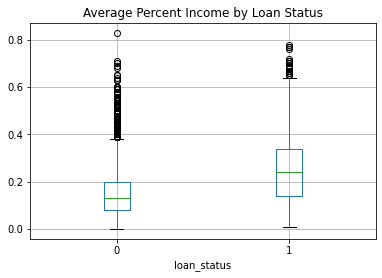

```python
# Create a box plot of percentage income by loan status
cr_loan.boxplot(column = ['loan_percent_income'], by = 'loan_status')
plt.title('Average Percent Income by Loan Status')
plt.suptitle('')
plt.show()
```

It looks like the average percentage of income for defaults is higher. This could indicate those recipients have a debt-to-income ratio that's already too high.

# Data Processing

### 2.1. Finding outliers with cross tables

Now you need to find and remove outliers you suspect might be in the data. For this exercise, you can use cross tables and aggregate functions.

Have a look at the `person_emp_length` column. You've used the `aggfunc = 'mean'` argument to see the average of a numeric column before, but to detect outliers you can use other functions like `min` and `max`.

It may not be possible for a person to have an employment length of less than 0 or greater than 60. You can use cross tables to check the data and see if there are any instances of this!

```python
# Create the cross table for loan status, home ownership, and the max employment length
pd.crosstab(cr_loan['loan_status'],cr_loan['person_home_ownership'],
        values=cr_loan['person_emp_length'], aggfunc='max')
```

| person_home_ownership loan_status | MORTGAGE | OTHER | OWN | RENT |
| --- | --- | --- | --- | --- |
| 0 | 123.0 | 24.0 | 31.0 | 41.0 |
| 1 | 34.0 | 11.0 | 17.0 | 123.0 |

```python
# Create an array of indices where employment length is greater than 60
indices = cr_loan[cr_loan['person_emp_length'] > 60].index

# Drop the records from the data based on the indices and create a new dataframe
cr_loan_new = cr_loan.drop(indices)

# Create the cross table from earlier and include minimum employment length
pd.crosstab(cr_loan_new['loan_status'],cr_loan_new['person_home_ownership'],
            values=cr_loan_new['person_emp_length'], aggfunc=['min','max'])
```

| person_home_ownership loan_status | min MORTGAGE | min OTHER | min OWN | min RENT | max MORTGAGE | max OTHER | max OWN | max RENT |
| --- | --- | --- | --- | --- | --- | --- | --- | --- |
| 0 | 0.0 | 0.0 | 0.0 | 0.0 | 38.0 | 24.0 | 31.0 | 41.0 |
| 1 | 0.0 | 0.0 | 0.0 | 0.0 | 34.0 | 11.0 | 17.0 | 27.0 |

### 2.2. Visualizing credit outliers

You discovered outliers in `person_emp_length` where values greater than 60 were far above the norm. `person_age` is another column in which a person can use a common sense approach to say it is very unlikely that a person applying for a loan will be over 100 years old.

Visualizing the data here can be another easy way to detect outliers. You can use other numeric columns like `loan_amnt` and `loan_int_rate` to create plots with `person_age` to search for outliers.

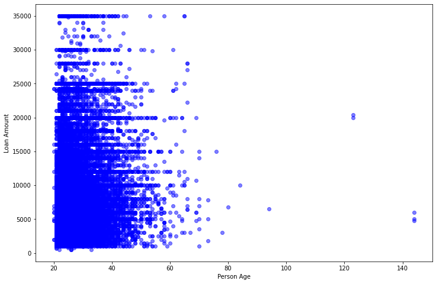

```python
# Create the scatter plot for age and amount
fig = plt.figure(figsize=(12,8))
plt.scatter(cr_loan['person_age'], cr_loan['loan_amnt'], c='blue', alpha=0.5)
plt.xlabel("Person Age")
plt.ylabel("Loan Amount")
plt.show()
```

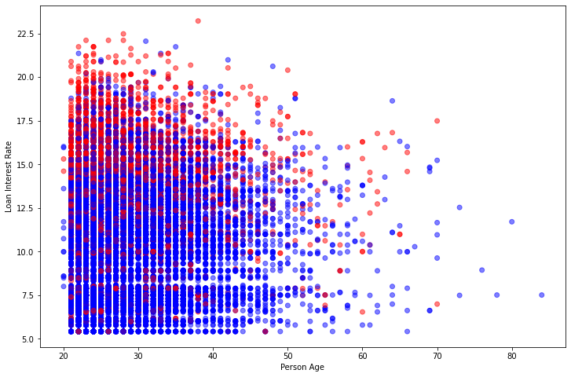

```python
import matplotlib.colors

# Use Pandas to drop the record from the data frame and create a new one
cr_loan = cr_loan.drop(cr_loan[cr_loan['person_age'] > 100].index)

# Create a scatter plot of age and interest rate
colors = ["blue","red"]
fig = plt.figure(figsize=(12,8))
plt.scatter(cr_loan['person_age'], cr_loan['loan_int_rate'],
            c = cr_loan['loan_status'],
            cmap = matplotlib.colors.ListedColormap(colors),
            alpha=0.5)
plt.xlabel("Person Age")
plt.ylabel("Loan Interest Rate")
plt.show()
```

Notice that in the last plot we have `loan_status` as a label for colors. This shows a different color depending on the class. In this case, it's loan default and non-default, and it looks like there are more defaults with high interest rates.

### 2.3. Replacing missing credit data

Now, you should check for missing data. If you find missing data within `loan_status`, you would not be able to use the data for predicting probability of default because you wouldn't know if the loan was a default or not. Missing data within `person_emp_length` would not be as damaging, but would still cause training errors.

So, check for missing data in the `person_emp_length` column and replace any missing values with the median.

```python
# Print a null value column array
print(cr_loan.columns[cr_loan.isnull().any()])

# Print the top five rows with nulls for employment length
print(cr_loan[cr_loan['person_emp_length'].isnull()].head())

# Impute the null values with the median value for all employment lengths
cr_loan['person_emp_length'].fillna((cr_loan['person_emp_length'].median()), inplace=True)
```

```
Index(['person_emp_length', 'loan_int_rate'], dtype='object')
     person_age  person_income person_home_ownership  person_emp_length  \
105          22          12600              MORTGAGE                NaN
222          24         185000              MORTGAGE                NaN
379          24          16800              MORTGAGE                NaN
407          25          52000                  RENT                NaN
408          22          17352              MORTGAGE                NaN

           loan_intent loan_grade  loan_amnt  loan_int_rate  loan_status  \
105           PERSONAL          A       2000           5.42            1
222          EDUCATION          B      35000          12.42            0
379  DEBTCONSOLIDATION          A       3900            NaN            1
407           PERSONAL          B      24000          10.74            1
408          EDUCATION          C       2250          15.27            0

     loan_percent_income cb_person_default_on_file  cb_person_cred_hist_length
105                 0.16                         N                           4
222                 0.19                         N                           2
379                 0.23                         N                           3
407                 0.46                         N                           2
408                 0.13                         Y                           3
```

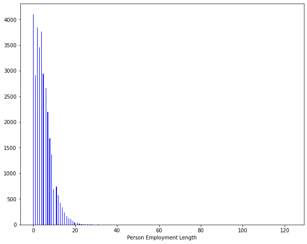

```python
# Create a histogram of employment length
fig = plt.figure(figsize=(10,8))
plt.hist(cr_loan['person_emp_length'], bins='auto', color='blue')
plt.xlabel("Person Employment Length")
plt.show()
```

You replaced missing data in `person_emp_length`, but in the previous exercise you saw that `loan_int_rate` has missing data as well.

Similar to having missing data within `loan_status`, having missing data within `loan_int_rate` will make predictions difficult.

Because interest rates are set by your company, having missing data in this column is very strange. It's possible that data ingestion issues created errors, but you cannot know for sure. For now, it's best to `.drop()` these records before moving forward.

```python
# Print the number of nulls
print(cr_loan['loan_int_rate'].isnull().sum())

# Store the array on indices
indices = cr_loan[cr_loan['loan_int_rate'].isnull()].index

# Save the new data without missing data
cr_loan = cr_loan.drop(indices)
```

```
3115
```

```python
print('Number of samples after data preprocessing = {}'.format(cr_loan.shape[0]))
cr_loan.isnull().sum()
```

```
Number of samples after data preprocessing = 29461
```

```
person_age                    0
person_income                 0
person_home_ownership         0
person_emp_length             0
loan_intent                   0
loan_grade                    0
loan_amnt                     0
loan_int_rate                 0
loan_status                   0
loan_percent_income           0
cb_person_default_on_file     0
cb_person_cred_hist_length    0
dtype: int64
```

# Logistic Regression for Defaults

### 3.1. Logistic regression basics

Think back to the final scatter plot from chapter 1 which showed more defaults with high `loan_int_rate`. Interest rates are easy to understand, but what how useful are they for predicting the probability of default?

Since you haven't tried predicting the probability of default yet, test out creating and training a logistic regression model with just `loan_int_rate`. Also check the model's internal parameters, which are like settings, to see the structure of the model with this one column.

```python
from sklearn.linear_model import LogisticRegression
import numpy as np

# Create the X and y data sets
X = cr_loan[['loan_int_rate']]
y = cr_loan[['loan_status']]

# Create and fit a logistic regression model
clf_logistic_single = LogisticRegression()
clf_logistic_single.fit(X, np.ravel(y))

# Print the parameters of the model
print(clf_logistic_single.get_params())

# Print the intercept of the model
print(clf_logistic_single.intercept_)
```

```
{'C': 1.0, 'class_weight': None, 'dual': False, 'fit_intercept': True, 'intercept_scaling': 1, 'l1_ratio': None, 'max_iter': 100, 'multi_class': 'auto', 'n_jobs': None, 'penalty': 'l2', 'random_state': None, 'solver': 'lbfgs', 'tol': 0.0001, 'verbose': 0, 'warm_start': False}
[-4.45848133]
```

### 3.2. Multivariate logistic regression

Generally, you won't use only loan_int_rate to predict the probability of default. You will want to use all the data you have to make predictions.

With this in mind, try training a new model with different columns, called features, from the cr_loan*clean data. Will this model differ from the first one? For this, you can easily check the .intercept* of the logistic regression. Remember that this is the y-intercept of the function and the overall log-odds of non-default.

```python
# Create X data for the model
X_multi = cr_loan[['loan_int_rate','person_emp_length']]

# Create a set of y data for training
y = cr_loan[['loan_status']]

# Create and train a new logistic regression
clf_logistic_multi = LogisticRegression(solver='lbfgs').fit(X_multi, np.ravel(y))

# Print the intercept of the model
print(clf_logistic_multi.intercept_)
```

```
[-4.22515925]
```

```python
from sklearn.model_selection import train_test_split

# Create the X and y data sets
X = cr_loan[['loan_int_rate','person_emp_length','person_income']]
y = cr_loan[['loan_status']]

# Use test_train_split to create the training and test sets
X_train, X_test, y_train, y_test = train_test_split(X, y, test_size=.4, random_state=123)

# Create and fit the logistic regression model
clf_logistic = LogisticRegression(solver='lbfgs').fit(X_train, np.ravel(y_train))

# Print the models coefficients
print(clf_logistic.coef_)
```

```
[[ 8.56591914e-02 -6.47642990e-02 -3.27795127e-05]]
```

### 3.3. One-hot encoding credit data

It's time to prepare the non-numeric columns so they can be added to your `LogisticRegression()` model.

Once the new columns have been created using one-hot encoding, you can concatenate them with the numeric columns to create a new data frame which will be used throughout the rest of the course for predicting probability of default.

Remember to only one-hot encode the non-numeric columns. Doing this to the numeric columns would create an incredibly wide data set!

```python
# Create two data sets for numeric and non-numeric data
cred_num = cr_loan.select_dtypes(exclude=['object'])
cred_str = cr_loan.select_dtypes(include=['object'])

# One-hot encode the non-numeric columns
cred_str_onehot = pd.get_dummies(cred_str)

# Union the one-hot encoded columns to the numeric ones
cr_loan_prep = pd.concat([cred_num, cred_str_onehot], axis=1)

# Print the columns in the new data set
print(cr_loan_prep.columns)
```

```
Index(['person_age', 'person_income', 'person_emp_length', 'loan_amnt',
       'loan_int_rate', 'loan_status', 'loan_percent_income',
       'cb_person_cred_hist_length', 'person_home_ownership_MORTGAGE',
       'person_home_ownership_OTHER', 'person_home_ownership_OWN',
       'person_home_ownership_RENT', 'loan_intent_DEBTCONSOLIDATION',
       'loan_intent_EDUCATION', 'loan_intent_HOMEIMPROVEMENT',
       'loan_intent_MEDICAL', 'loan_intent_PERSONAL', 'loan_intent_VENTURE',
       'loan_grade_A', 'loan_grade_B', 'loan_grade_C', 'loan_grade_D',
       'loan_grade_E', 'loan_grade_F', 'loan_grade_G',
       'cb_person_default_on_file_N', 'cb_person_default_on_file_Y'],
      dtype='object')
```

### 3.4. Predicting probability of default

All of the data processing is complete and it's time to begin creating predictions for probability of default. You want to train a `LogisticRegression()` model on the data, and examine how it predicts the probability of default.

So that you can better grasp what the model produces with `predict_proba`, you should look at an example record alongside the predicted probability of default. How do the first five predictions look against the actual values of `loan_status`?

```python
# Create the X and y data sets
X = cr_loan_prep.drop('loan_status', axis=1)
y = cr_loan_prep[['loan_status']]

# Use test_train_split to create the training and test sets
X_train, X_test, y_train, y_test = train_test_split(X, y, test_size=.4, random_state=123)
```

```python
# Train the logistic regression model on the training data
clf_logistic = LogisticRegression(solver='lbfgs').fit(X_train, np.ravel(y_train))

# Create predictions of probability for loan status using test data
preds = clf_logistic.predict_proba(X_test)

# Create dataframes of first five predictions, and first five true labels
preds_df = pd.DataFrame(preds[:,1][0:20], columns = ['prob_default'])
true_df = y_test.head(20)

# Concatenate and print the two data frames for comparison
print(pd.concat([true_df.reset_index(drop = True), preds_df], axis = 1))
```

```
    loan_status  prob_default
0             0      0.130876
1             0      0.049563
2             0      0.137133
3             0      0.239448
4             0      0.084269
5             0      0.171236
6             0      0.298377
7             0      0.392559
8             0      0.106910
9             0      0.114760
10            0      0.147740
11            0      0.406887
12            1      0.243232
13            0      0.289777
14            1      0.094794
15            0      0.367257
16            0      0.122269
17            0      0.019955
18            0      0.100129
19            0      0.085291
```

### 3.5. Default classification reporting

It's time to take a closer look at the evaluation of the model. Here is where setting the threshold for probability of default will help you analyze the model's performance through classification reporting.

Creating a data frame of the probabilities makes them easier to work with, because you can use all the power of `pandas`. Apply the threshold to the data and check the value counts for both classes of `loan_status` to see how many predictions of each are being created. This will help with insight into the scores from the classification report.

```python
from sklearn.metrics import classification_report

# Create a dataframe for the probabilities of default
preds_df = pd.DataFrame(preds[:,1], columns = ['prob_default'])

# Reassign loan status based on the threshold
preds_df['loan_status'] = preds_df['prob_default'].apply(lambda x: 1 if x > 0.50 else 0)

# Print the row counts for each loan status
print(preds_df['loan_status'].value_counts())

# Print the classification report
target_names = ['Non-Default', 'Default']
print(classification_report(y_test, preds_df['loan_status'], target_names=target_names))
```

```
0    11221
1      564
Name: loan_status, dtype: int64
              precision    recall  f1-score   support

 Non-Default       0.81      0.98      0.89      9190
     Default       0.75      0.16      0.27      2595

    accuracy                           0.80     11785
   macro avg       0.78      0.57      0.58     11785
weighted avg       0.79      0.80      0.75     11785
```

The **recall** for defaults is 0.16 meaning 16% of our true defaults were predicted correctly by the Logistic Regression model.

### 3.6. Visually scoring credit models

Now, you want to visualize the performance of the model. In ROC charts, the X and Y axes are two metrics you've already looked at: the false positive rate (fall-out), and the true positive rate (sensitivity).

```
The accuracy is: 0.8039032668646585
```

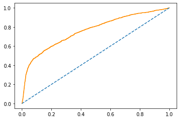

```
The AUC score is: 0.7620597071877995
```

```python
from sklearn.metrics import roc_curve, roc_auc_score

# Create predictions and store them in a variable
preds = clf_logistic.predict_proba(X_test)

# Print the accuracy score the model
print("The accuracy is: {}".format(clf_logistic.score(X_test, y_test)))

# Plot the ROC curve of the probabilities of default
prob_default = preds[:, 1]
fallout, sensitivity, thresholds = roc_curve(y_test, prob_default)
plt.plot(fallout, sensitivity, color = 'darkorange')
plt.plot([0, 1], [0, 1], linestyle='--')
plt.show()

# Compute the AUC and store it in a variable
auc = roc_auc_score(y_test, prob_default)
print("The AUC score is: {}".format(auc))
```

The **accuracy** for this model is about 80% and the **AUC score** is 76%. Notice that what the ROC chart shows us is the tradeoff between all values of our false positive rate (fallout) and true positive rate (sensitivity).

### 3.7. Thresholds and confusion matrices

You've looked at setting thresholds for defaults, but how does this impact overall performance? To do this, you can start by looking at the effects with confusion matrices.

Recall the confusion matrix as shown here:

[figure not shown]

Set different values for the threshold on probability of default, and use a confusion matrix to see how the changing values affect the model's performance.

```python
from sklearn.metrics import confusion_matrix

# Set the threshold for defaults to 0.5
preds_df['loan_status'] = preds_df['prob_default'].apply(lambda x: 1 if x > 0.5 else 0)

# Print the confusion matrix
cmtx1 = pd.DataFrame(confusion_matrix(y_test,preds_df['loan_status'], labels=[0,1]),
             index=['Actual=0', 'Actual=1'],
             columns=['Predicted=0', 'Predicted=1']
)
cmtx1
```

|  | Predicted=0 | Predicted=1 |
| --- | --- | --- |
| Actual=0 | 9050 | 140 |
| Actual=1 | 2171 | 424 |

```python
# Set the threshold for defaults to 0.4
preds_df['loan_status'] = preds_df['prob_default'].apply(lambda x: 1 if x > 0.4 else 0)

# Print the confusion matrix
cmtx2 = pd.DataFrame(confusion_matrix(y_test,preds_df['loan_status'], labels=[0,1]),
             index=['Actual=0', 'Actual=1'],
             columns=['Predicted=0', 'Predicted=1']
)
cmtx2
```

|  | Predicted=0 | Predicted=1 |
| --- | --- | --- |
| Actual=0 | 8515 | 675 |
| Actual=1 | 1410 | 1185 |

```python
print("Default recall for threshold=0.5 is {}".format(cmtx1.loc['Actual=1','Predicted=1'] / (cmtx1.loc['Actual=1','Predicted=1'] + cmtx1.loc['Actual=1','Predicted=0'])))
print("Default recall for threshold=0.4 is {}".format(cmtx2.loc['Actual=1','Predicted=1'] / (cmtx2.loc['Actual=1','Predicted=1'] + cmtx2.loc['Actual=1','Predicted=0'])))
```

```
Default recall for threshold=0.5 is 0.16339113680154144
Default recall for threshold=0.4 is 0.45664739884393063
```

The value for default recall at this threshold is actually pretty high! You can check out the non-default recalls as well to see how the threshold affected those values.

### 3.8. How thresholds affect performance

Setting the threshold to `0.4` shows promising results for model evaluation. Now you can assess the financial impact using the default recall which is selected from the classification reporting using the function `precision_recall_fscore_support()`.

For this, you will estimate the amount of unexpected loss using the default recall to find what proportion of defaults you did **not** catch with the new threshold. This will be a dollar amount which tells you how much in losses you would have if all the unfound defaults were to default all at once.

```python
from sklearn.metrics import precision_recall_fscore_support, accuracy_score

# Get average loan amount
avg_loan_amnt = cr_loan['loan_amnt'].mean()

# Reassign the values of loan status based on the new threshold
preds_df['loan_status'] = preds_df['prob_default'].apply(lambda x: 1 if x > 0.4 else 0)

# Store the number of loan defaults from the prediction data
num_defaults = preds_df['loan_status'].value_counts()[1]

# Store the default recall from the classification report
default_recall = precision_recall_fscore_support(y_test,preds_df['loan_status'])[1][1]

# Calculate the estimated impact of the new default recall rate
print("The estimated impact of the new default recall rate: {}".format(avg_loan_amnt * num_defaults * (1 - default_recall)))
```

```
The estimated impact of the new default recall rate: 9686759.780589722
```

By our estimates, this loss would be around $9.6 million. That seems like a lot! Try rerunning this code with threshold values of `0.3` and `0.5`. Do you see the estimated losses changing? How do we find a good threshold value based on these metrics alone?

### 3.9. Threshold selection

You know there is a trade off between metrics like default recall, non-default recall, and model accuracy. One easy way to approximate a good starting threshold value is to look at a plot of all three using `matplotlib`. With this graph, you can see how each of these metrics look as you change the threshold values and find the point at which the performance of all three is good enough to use for the credit data.

```python
threshs = [0.2,0.225,0.25,0.275,0.3,0.325,0.35,0.375,0.4,0.425,0.45,0.475,0.5,0.525,0.55,0.575,0.6,0.625,0.65]

def_recalls = []

nondef_recalls = []

accs = []

for thresh in threshs:
    preds_df['loan_status'] = preds_df['prob_default'].apply(lambda x: 1 if x > thresh else 0)
    # Store the number of loan defaults from the prediction data
    num_defaults = preds_df['loan_status'].value_counts()[1]

    # Store the default recall and non_default recall from the classification report
    default_recall = precision_recall_fscore_support(y_test,preds_df['loan_status'])[1][1]
    nondef_recall = precision_recall_fscore_support(y_test,preds_df['loan_status'])[1][0]

    # Store model accuracy in accs
    acc = accuracy_score(y_test,preds_df['loan_status'])
    accs.append(acc)

    # Append to result
    def_recalls.append(default_recall)
    nondef_recalls.append(nondef_recall)
```

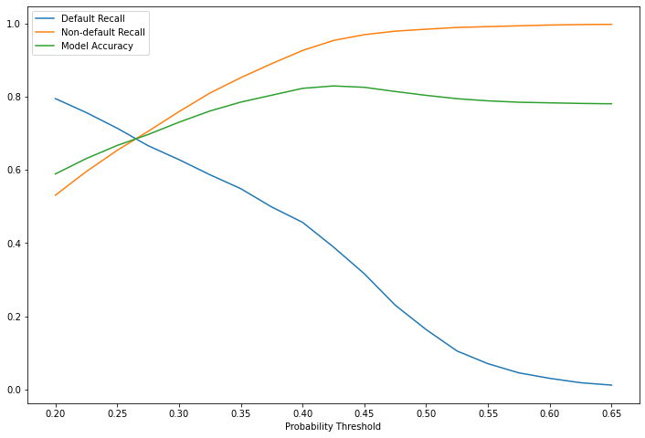

```python
ticks = [0.2, 0.25, 0.3, 0.35, 0.4, 0.45, 0.5, 0.55, 0.6, 0.65]

fig = plt.figure(figsize=(12,8))
plt.plot(threshs,def_recalls)
plt.plot(threshs,nondef_recalls)
plt.plot(threshs,accs)
plt.xlabel("Probability Threshold")
plt.xticks(ticks)
plt.legend(["Default Recall","Non-default Recall","Model Accuracy"])
plt.show()
```

Approximately what starting threshold value would maximize these scores evenly? \ **Ans:** 0.275

This is the easiest pattern to see on this graph, because it's the point where all three lines converge. This threshold would make a great starting point, but declaring all loans about 0.275 to be a default is probably not practical.

# 4. Gradient Boosted Trees Using XGBoost

### 4.1. Trees for defaults

```python
# Train a model
import xgboost as xgb
clf_gbt = xgb.XGBClassifier().fit(X_train, np.ravel(y_train))

# Predict with a model
gbt_preds = clf_gbt.predict_proba(X_test)

# Create dataframes of first five predictions, and first five true labels
preds_df = pd.DataFrame(gbt_preds[:,1][0:20], columns = ['prob_default'])
true_df = y_test.head(20)

# Concatenate and print the two data frames for comparison
print(pd.concat([true_df.reset_index(drop = True), preds_df], axis = 1))
```

```
    loan_status  prob_default
0             0      0.002017
1             0      0.024879
2             0      0.025256
3             0      0.015450
4             0      0.003830
5             0      0.029546
6             0      0.061059
7             0      0.002031
8             0      0.040354
9             0      0.013891
10            0      0.040747
11            0      0.678550
12            1      0.953624
13            0      0.048739
14            1      0.996780
15            0      0.048977
16            0      0.053557
17            0      0.042028
18            0      0.012177
19            0      0.006733
```

### 4.2. Gradient boosted portfolio performance

At this point you've looked at predicting probability of default using both a `LogisticRegression()` and `XGBClassifier()`. You've looked at some scoring and have seen samples of the predictions, but what is the overall affect on portfolio performance? Try using expected loss as a scenario to express the importance of testing different models.

[figure not shown]

```python
# Train the logistic regression model on the training data
clf_logistic = LogisticRegression(solver='lbfgs').fit(X_train, np.ravel(y_train))

# Create predictions of probability for loan status using test data
preds = clf_logistic.predict_proba(X_test)

# Create dataframes of prob_default for LogisticRegression()
preds_logistic_df = pd.DataFrame(preds[:,1], columns = ['lr_prob_default'])

# Create dataframes of prob_default for XGClassifier
preds_xgb_df = pd.DataFrame(gbt_preds[:,1], columns = ['gbt_prob_default'])

# Concatenating the DataFrames
portfolio = pd.concat([preds_logistic_df['lr_prob_default'],preds_xgb_df['gbt_prob_default'],X_test['loan_amnt'].reset_index(drop=True)], axis=1)
portfolio['lgd'] = 0.2

# Print the first five rows of the portfolio data frame
portfolio.head()
```

|  | lr_prob_default | gbt_prob_default | loan_amnt | lgd |
| --- | --- | --- | --- | --- |
| 0 | 0.130876 | 0.002017 | 3000 | 0.2 |
| 1 | 0.049563 | 0.024879 | 35000 | 0.2 |
| 2 | 0.137133 | 0.025256 | 15000 | 0.2 |
| 3 | 0.239448 | 0.015450 | 10800 | 0.2 |
| 4 | 0.084269 | 0.003830 | 14000 | 0.2 |

```python
# Create expected loss columns for each model using the formula
portfolio['gbt_expected_loss'] = portfolio['gbt_prob_default'] * portfolio['lgd'] * portfolio['loan_amnt']
portfolio['lr_expected_loss'] = portfolio['lr_prob_default'] * portfolio['lgd'] * portfolio['loan_amnt']

# Print the sum of the expected loss for lr
print('LR expected loss: ', np.sum(portfolio['lr_expected_loss']))

# Print the sum of the expected loss for gbt
print('GBT expected loss: ', np.sum(portfolio['gbt_expected_loss']))
```

```
LR expected loss:  5529109.696617971
GBT expected loss:  5446513.597627496
```

```python
# Predict the labels for loan status
gbt_preds = clf_gbt.predict(X_test)

# Check the values created by the predict method
print(gbt_preds)

# Print the classification report of the model
target_names = ['Non-Default', 'Default']
print(classification_report(y_test, gbt_preds, target_names=target_names))
```

```
[0 0 0 ... 0 0 0]
              precision    recall  f1-score   support

 Non-Default       0.93      0.99      0.96      9190
     Default       0.96      0.74      0.83      2595

    accuracy                           0.93     11785
   macro avg       0.94      0.86      0.90     11785
weighted avg       0.94      0.93      0.93     11785
```

Wow. Have a look at the precision and recall scores! Remember the low default recall values we were getting from the `LogisticRegression()`? This model already appears to have serious potential.

### 4.3. Column importance and default prediction

When using multiple training sets with many different groups of columns, it's important to keep and eye on which columns matter and which do not. It can be expensive or time-consuming to maintain a set of columns even though they might not have any impact on `loan_status`.

```python
# Print the column importances from the model
print(clf_gbt.get_booster().get_score(importance_type = 'weight'))
```

[output not shown]

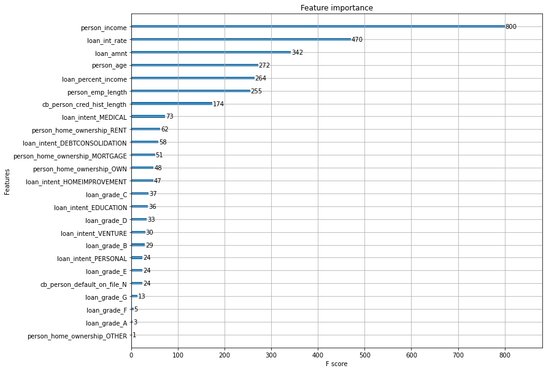

```python
# Plot the column importance for this model
ax = xgb.plot_importance(clf_gbt, importance_type = 'weight')
fig = ax.figure
fig.set_size_inches(12, 10)
plt.show()
```

### 4.4. Cross validating credit models

Credit loans and their data change over time, and it won't always look like what's been loaded into the current test sets. So, you can use cross-validation to try several smaller training and test sets which are derived from the original `X_train` and `y_train`.

Use the XGBoost function `cv()` to perform cross-validation. You will need to set up all the parameters for `cv()` to use on the test data.

```python
# Set the values for number of folds and stopping iterations
n_folds = 5
early_stopping = 10

# Set params
params = {'eval_metric': 'auc', 'objective': 'binary:logistic', 'seed': 123}

# Create the DTrain matrix for XGBoost
DTrain = xgb.DMatrix(X_train, label = y_train)

# Create the data frame of cross validations
cv_df = xgb.cv(params, DTrain, num_boost_round = 5, nfold=n_folds,
            early_stopping_rounds=early_stopping)

# Print the cross validations data frame
print(cv_df)
```

```
   train-auc-mean  train-auc-std  test-auc-mean  test-auc-std
0        0.901708       0.002892       0.896295      0.005814
1        0.909336       0.002976       0.904411      0.007504
2        0.915779       0.001982       0.910088      0.007943
3        0.921403       0.000900       0.913738      0.008054
4        0.924642       0.002095       0.916628      0.006639
```

### 4.5. Cross-validation scoring

Now, you should use cross-validation scoring with `cross_val_score()` to check the overall performance.

This is exercise presents an excellent opportunity to test out the use of the hyperparameters `learning_rate` and `max_depth`. Remember, hyperparameters are like settings which can help create optimum performance.

```python
from sklearn.model_selection import cross_val_score

# Create a gradient boosted tree model using two hyperparameters
gbt = xgb.XGBClassifier(learning_rate = 0.1, max_depth = 7)

# Calculate the cross validation scores for 4 folds
cv_scores = cross_val_score(gbt, X_train, np.ravel(y_train), cv = 4)

# Print the cross validation scores
print(cv_scores)

# Print the average accuracy and standard deviation of the scores
print("Average accuracy: %0.2f (+/- %0.2f)" % (cv_scores.mean(),
                                              cv_scores.std() * 2))
```

```
[0.93573207 0.93663725 0.9291695  0.93663725]
Average accuracy: 0.93 (+/- 0.01)
```

### 4.6. Undersampling training data

It's time to undersample the training set yourself with a few lines of code from Pandas. Once the undersampling is complete, you can check the value counts for `loan_status` to verify the results.

```python
# Concat the training sets
X_y_train = pd.concat([X_train.reset_index(drop = True),
                       y_train.reset_index(drop = True)], axis = 1)

# Get the cofunts of defaults and non-defaults
count_nondefault, count_default = X_y_train['loan_status'].value_counts()

# Create data sets for defaults and non-defaults
nondefaults = X_y_train[X_y_train['loan_status'] == 0]
defaults = X_y_train[X_y_train['loan_status'] == 1]

# Undersample the non-defaults
nondefaults_under = nondefaults.sample(count_default)

# Concatenate the undersampled nondefaults with defaults
X_y_train_under = pd.concat([nondefaults_under.reset_index(drop = True),
                             defaults.reset_index(drop = True)], axis = 0)

# Print the value counts for loan status
print(X_y_train_under['loan_status'].value_counts())
```

```
1    3869
0    3869
Name: loan_status, dtype: int64
```

```python
# Create the X and y data sets
X2 = X_y_train_under.drop('loan_status', axis=1)
y2 = X_y_train_under[['loan_status']]

X2_train, X2_test, y2_train, y2_test = train_test_split(X2, y2, test_size=.4, random_state=123)
```

```python
clf_gbt2 = xgb.XGBClassifier().fit(X2_train, np.ravel(y2_train))

# Predict with a model
gbt2_preds = clf_gbt2.predict(X_test)
```

### 4.7. Undersampled tree performance

You've undersampled the training set and trained a model on the undersampled set.

The performance of the model's predictions not only impact the probability of default on the test set, but also on the scoring of new loan applications as they come in. You also now know that it is even more important that the recall of defaults be high, because a default predicted as non-default is more costly.

The next crucial step is to compare the new model's performance to the original model.

```python
# Check the classification reports
target_names = ['Non-Default', 'Default']
print(classification_report(y_test, gbt_preds, target_names=target_names))
print(classification_report(y_test, gbt2_preds, target_names=target_names))
```

```
              precision    recall  f1-score   support

 Non-Default       0.93      0.99      0.96      9190
     Default       0.96      0.74      0.83      2595

    accuracy                           0.93     11785
   macro avg       0.94      0.86      0.90     11785
weighted avg       0.94      0.93      0.93     11785

              precision    recall  f1-score   support

 Non-Default       0.94      0.91      0.93      9190
     Default       0.72      0.81      0.76      2595

    accuracy                           0.89     11785
   macro avg       0.83      0.86      0.84     11785
weighted avg       0.89      0.89      0.89     11785
```

```python
# Print the confusion matrix for both old and new models
print(confusion_matrix(y_test,gbt_preds))
print(confusion_matrix(y_test,gbt2_preds))
```

```
[[9103   87]
 [ 684 1911]]
[[8353  837]
 [ 492 2103]]
```

```python
# Print and compare the AUC scores of the old and new models
print(roc_auc_score(y_test, gbt_preds))
print(roc_auc_score(y_test, gbt2_preds))
```

```
0.8634746866095969
0.8596636831942235
```

# 5. Model Evaluation and Implementation

### 5.1. Comparing model reports

You've used logistic regression models and gradient boosted trees. It's time to compare these two to see which model will be used to make the final predictions.

One of the easiest first steps for comparing different models' ability to predict the probability of default is to look at their metrics from the `classification_report()`. With this, you can see many different scoring metrics side-by-side for each model. Because the data and models are normally unbalanced with few defaults, focus on the metrics for defaults for now.

A cutoff of 0.4 was used for each.

```python
# Train the logistic regression model on the training data
clf_logistic = LogisticRegression(solver='lbfgs').fit(X_train, np.ravel(y_train))

# Create predictions of probability for loan status using test data
preds_lr = clf_logistic.predict_proba(X_test)

preds_df_lr = pd.DataFrame(preds_lr[:,1], columns = ['prob_default'])

preds_df_lr['loan_status'] = preds_df_lr['prob_default'].apply(lambda x: 1 if x > 0.4 else 0)
```

```python
# Train the gradient boosted model
clf_gbt = xgb.XGBClassifier().fit(X_train, np.ravel(y_train))

# Predict with a model
preds_gbt = clf_gbt.predict_proba(X_test)

preds_df_gbt = pd.DataFrame(preds_gbt[:,1], columns = ['prob_default'])

preds_df_gbt['loan_status'] = preds_df_gbt['prob_default'].apply(lambda x: 1 if x > 0.4 else 0)
```

```python
# Print the logistic regression classification report
target_names = ['Non-Default', 'Default']
print(classification_report(y_test, preds_df_lr['loan_status'], target_names=target_names))

# Print the gradient boosted tree classification report
print(classification_report(y_test, preds_df_gbt['loan_status'], target_names=target_names))

# Print the default F-1 scores for the logistic regression
print("The default F-1 scores for the logistic regression : {}".
      format(precision_recall_fscore_support(y_test,preds_df_lr['loan_status'], average = 'macro')[2]))

# Print the default F-1 scores for the gradient boosted tree
print("The default F-1 scores for the gradient boosted tree: {}".
      format(precision_recall_fscore_support(y_test,preds_df_gbt['loan_status'], average = 'macro')[2]))
```

```
              precision    recall  f1-score   support

 Non-Default       0.86      0.93      0.89      9190
     Default       0.64      0.46      0.53      2595

    accuracy                           0.82     11785
   macro avg       0.75      0.69      0.71     11785
weighted avg       0.81      0.82      0.81     11785

              precision    recall  f1-score   support

 Non-Default       0.93      0.98      0.96      9190
     Default       0.92      0.76      0.83      2595

    accuracy                           0.93     11785
   macro avg       0.93      0.87      0.89     11785
weighted avg       0.93      0.93      0.93     11785

The default F-1 scores for the logistic regression : 0.7114549453027088
The default F-1 scores for the gradient boosted tree: 0.8939374862534395
```

Great! There is a noticeable difference between these two models. Do you see that the scores from the `classification_report()` are all higher for the gradient boosted tree? This means the tree model is better in all of these aspects. Let's check the ROC curve.

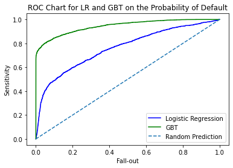

```python
#ROC chart components
fallout_lr, sensitivity_lr, thresholds_lr = roc_curve(y_test, preds_df_lr['prob_default'])
fallout_gbt, sensitivity_gbt, thresholds_gbt = roc_curve(y_test, preds_df_gbt['prob_default'])

# ROC Chart with both
plt.plot(fallout_lr, sensitivity_lr, color = 'blue', label='%s' % 'Logistic Regression')
plt.plot(fallout_gbt, sensitivity_gbt, color = 'green', label='%s' % 'GBT')
plt.plot([0, 1], [0, 1], linestyle='--', label='%s' % 'Random Prediction')
plt.title("ROC Chart for LR and GBT on the Probability of Default")
plt.xlabel('Fall-out')
plt.ylabel('Sensitivity')
plt.legend()
plt.show()
```

### 5.2. Comparing with ROCs

You should use ROC charts and AUC scores to compare the two models. Sometimes, visuals can really help you and potential business users understand the differences between the various models under consideration.

With the graph in mind, you will be more equipped to make a decision. The lift is how far the curve is from the random prediction. The AUC is the area between the curve and the random prediction. The model with more lift, and a higher AUC, is the one that's better at making predictions accurately.

```python
# Print the logistic regression AUC with formatting
print("Logistic Regression AUC Score: %0.2f" % roc_auc_score(y_test, preds_df_lr['prob_default']))

# Print the gradient boosted tree AUC with formatting
print("Gradient Boosted Tree AUC Score: %0.2f" % roc_auc_score(y_test, preds_df_gbt['prob_default']))
```

```
Logistic Regression AUC Score: 0.76
Gradient Boosted Tree AUC Score: 0.94
```

Wow! Look at the ROC curve for the gradient boosted tree. Not only is the lift much higher, the calculated AUC score is also quite a bit higher. It's beginning to look like the gradient boosted tree is best. Let's check the calibration to be sure.

### 5.3. Calibration curves

You now know that the gradient boosted tree clf_gbt has the best overall performance. You need to check the calibration of the two models to see how stable the default prediction performance is across probabilities. You can use a chart of each model's calibration to check this by calling the `calibration_curve()` function.

```python
from sklearn.calibration import calibration_curve

frac_of_pos_lr, mean_pred_val_lr = calibration_curve(y_test, preds_df_lr['prob_default'], n_bins = 16)
frac_of_pos_gbt, mean_pred_val_gbt = calibration_curve(y_test, preds_df_gbt['prob_default'], n_bins = 16)
```

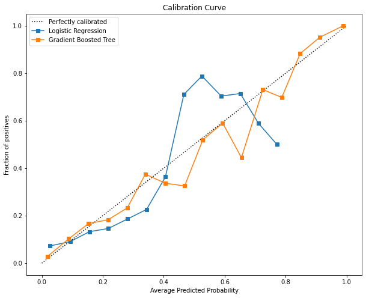

```python
# Add the calibration curve for the gradient boosted tree
fig = plt.figure(figsize=(10,8))
plt.plot([0, 1], [0, 1], 'k:', label='Perfectly calibrated')
plt.plot(mean_pred_val_lr, frac_of_pos_lr,
         's-', label='%s' % 'Logistic Regression')
plt.plot(mean_pred_val_gbt, frac_of_pos_gbt,
         's-', label='%s' % 'Gradient Boosted Tree')
plt.ylabel('Fraction of positives')
plt.xlabel('Average Predicted Probability')
plt.legend()
plt.title('Calibration Curve')
plt.show()
```

Notice that for the logistic regression, the calibration for probabilities starts off great but then gets more erratic as it the average probability approaches `0.4`. Something similar happens to the gradient boosted tree around `0.5`, but the model eventually stabilizes. We will be focusing on only the gbt model from now on.

### 5.4. Acceptance rates

Setting an acceptance rate and calculating the threshold for that rate can be used to set the percentage of new loans you want to accept. For this exercise, assume the test data is a fresh batch of new loans. You will need to use the `quantile()` function from numpy to calculate the threshold.

The threshold should be used to assign new `loan_status` values. Does the number of defaults and non-defaults in the data change?

```python
test_pred = clf_gbt.predict_proba(X_test)

test_pred_df = pd.DataFrame(preds_gbt[:,1], columns = ['prob_default'])
```

```python
# Check the statistics of the probabilities of default
print(test_pred_df['prob_default'].describe())

# Calculate the threshold for a 85% acceptance rate
threshold_85 = np.quantile(test_pred_df['prob_default'], 0.85)

# Apply acceptance rate threshold
test_pred_df['loan_status'] = test_pred_df['prob_default'].apply(lambda x: 1 if x > threshold_85 else 0)

# Print the counts of loan status after the threshold
print(test_pred_df['loan_status'].value_counts())
```

```
count    11785.000000
mean         0.214005
std          0.345290
min          0.000005
25%          0.009908
50%          0.043287
75%          0.184309
max          0.999993
Name: prob_default, dtype: float64
0    10017
1     1768
Name: loan_status, dtype: int64
```

In the results of `.describe()` do you see how it's not until 75% that you start to see double-digit numbers? That's because the majority of our test set is non-default loans. Next let's look at how the acceptance rate and threshold split up the data.

### 5.5. Visualizing quantiles of acceptance

You know how `quantile()` works to compute a threshold, and you've seen an example of what it does to split the loans into accepted and rejected. What does this threshold look like for the test set, and how can you visualize it?

To check this, you can create a histogram of the probabilities and add a reference line for the threshold. With this, you can visually show where the threshold exists in the distribution.

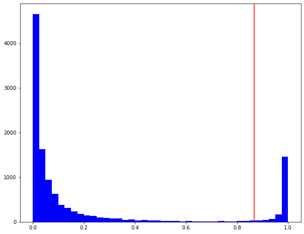

```python
# Plot the predicted probabilities of default
fig = plt.figure(figsize=(10,8))
plt.hist(test_pred_df['prob_default'], color = 'blue', bins = 40)

# Calculate the threshold with quantile
threshold = np.quantile(test_pred_df['prob_default'], 0.85)

# Add a reference line to the plot for the threshold
plt.axvline(x = threshold, color = 'red')
plt.show()
```

Here, you can see where the threshold is on the range of predicted probabilities. Not only can you see how many loans will be accepted (left side), but also how many loans will be rejected (right side). I recommend that you re-run this code with different threshold values to better understand how this affects the acceptance rate.

### 5.6. Bad rates

With acceptance rate in mind, you can now analyze the bad rate within the accepted loans. This way you will be able to see the percentage of defaults that have been accepted.

Think about the impact of the acceptance rate and bad rate. We set an acceptance rate to have fewer defaults in the portfolio because defaults are more costly. Will the bad rate be less than the percentage of defaults in the test data?

```python
test_pred_df.rename(columns={"loan_status": "pred_loan_status"}, inplace=True)

test_pred_df['true_loan_status'] = y_test.reset_index(drop=True)

# Print the top 5 rows of the new data frame
print(test_pred_df.head())

# Create a subset of only accepted loans
accepted_loans = test_pred_df[test_pred_df['pred_loan_status'] == 0]

# Calculate the bad rate
print(np.sum(accepted_loans['true_loan_status']) / accepted_loans['true_loan_status'].count())
```

```
   prob_default  pred_loan_status  true_loan_status
0      0.002017                 0                 0
1      0.024879                 0                 0
2      0.025256                 0                 0
3      0.015450                 0                 0
4      0.003830                 0                 0
0.08305880003993212
```

This bad rate doesn't look half bad! The bad rate with the threshold set by the 85% `quantile()` is about 8%. This means that of all the loans we've decided to accept from the test set, only 8% were actual defaults! If we accepted all loans, the percentage of defaults would be around 22%.

### 5.7. Acceptance rate impact

Now, look at the `loan_amnt` of each loan to understand the impact on the portfolio for the acceptance rates. You can use cross tables with calculated values, like the average loan amount, of the new set of loans `X_test`. For this, you will multiply the number of each with an average `loan_amnt` value.

```python
test_pred_df['loan_amnt'] = X_test['loan_amnt'].reset_index(drop=True)
```

```python
# Print the statistics of the loan amount column
print(test_pred_df['loan_amnt'].describe())

# Store the average loan amount
avg_loan = np.mean(X_test['loan_amnt'])

# Set the formatting for currency, and print the cross tab
print(pd.crosstab(test_pred_df['true_loan_status'],
                  test_pred_df['pred_loan_status']).apply(lambda x: x * avg_loan, axis = 0))
```

```
count    11785.000000
mean      9534.212983
std       6238.203474
min        500.000000
25%       5000.000000
50%       8000.000000
75%      12000.000000
max      35000.000000
Name: loan_amnt, dtype: float64
pred_loan_status             0             1
true_loan_status
0                 8.757175e+07  4.767106e+04
1                 7.932465e+06  1.680882e+07
```

With this, we can see that our bad rate of about 8% represents an estimated loan value of about 7.9 million dollars. This may seem like a lot at first, but compare it to the total value of non-default loans! With this, we are ready to start talking about our acceptance strategy going forward.

### 5.8. Making the strategy table

Before you implement a strategy, you should first create a strategy table containing all the possible acceptance rates you wish to look at along with their associated bad rates and threshold values. This way, you can begin to see each part of your strategy and how it affects your portfolio.

```python
accept_rates = [1.0, 0.95, 0.9, 0.85, 0.8, 0.75, 0.7, 0.65, 0.6, 0.55, 0.5, 0.45, 0.4, 0.35, 0.3, 0.25, 0.2, 0.15, 0.1, 0.05]

thresholds = []
bad_rates = []



# Populate the arrays for the strategy table with a for loop
for rate in accept_rates:
    # Calculate the threshold for the acceptance rate
    thresh = np.quantile(preds_df_gbt['prob_default'], rate).round(3)
    # Add the threshold value to the list of thresholds
    thresholds.append(np.quantile(preds_df_gbt['prob_default'], rate).round(3))
    # Reassign the loan_status value using the threshold
    test_pred_df['pred_loan_status'] = test_pred_df['prob_default'].apply(lambda x: 1 if x > thresh else 0)
    # Create a set of accepted loans using this acceptance rate
    accepted_loans = test_pred_df[test_pred_df['pred_loan_status'] == 0]
    # Calculate and append the bad rate using the acceptance rate
    bad_rates.append(np.sum((accepted_loans['true_loan_status']) / len(accepted_loans['true_loan_status'])).round(3))
```

```python
# Create a data frame of the strategy table
strat_df = pd.DataFrame(zip(accept_rates, thresholds, bad_rates),
                        columns = ['Acceptance Rate','Threshold','Bad Rate'])

# Print the entire table
print(strat_df)
```

```
    Acceptance Rate  Threshold  Bad Rate
0              1.00      1.000     0.220
1              0.95      0.997     0.184
2              0.90      0.988     0.133
3              0.85      0.868     0.083
4              0.80      0.308     0.059
5              0.75      0.184     0.050
6              0.70      0.127     0.041
7              0.65      0.092     0.036
8              0.60      0.071     0.031
9              0.55      0.055     0.027
10             0.50      0.043     0.022
11             0.45      0.033     0.018
12             0.40      0.026     0.016
13             0.35      0.019     0.014
14             0.30      0.014     0.011
15             0.25      0.010     0.008
16             0.20      0.006     0.005
17             0.15      0.003     0.002
18             0.10      0.001     0.000
19             0.05      0.000     0.000
```

This uses our specific predictions on the credit data, and can be used to see the acceptance rates, bad rates, and financial impact all at once. One of these values has the highest estimated value.

### 5.9. Visualizing the strategy

Now you have the extended strategy table `strat_df`. The table is not so big that it's difficult to analyze, but visuals can help you see the overview all at once.

You should check at the distribution of each column with a box plot. If the distribution of `Acceptance Rate` looks the same as the `Bad Rate` column, that could be a problem. That means that the model's calibration is likely much worse than you thought.

You can also visualize the strategy curve with a line plot. The `Acceptance Rate` would be the independent variable with the `Bad Rate` as the dependent variable.

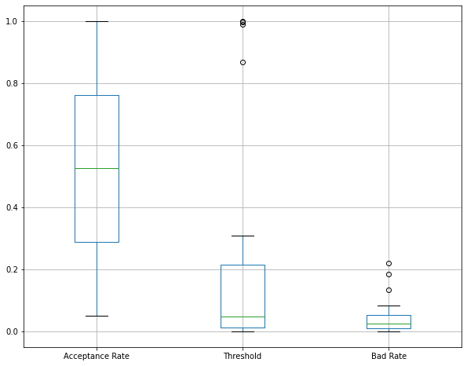

```python
# Visualize the distributions in the strategy table with a boxplot
fig = plt.figure(figsize=(10,8))
strat_df.boxplot()
plt.show()
```

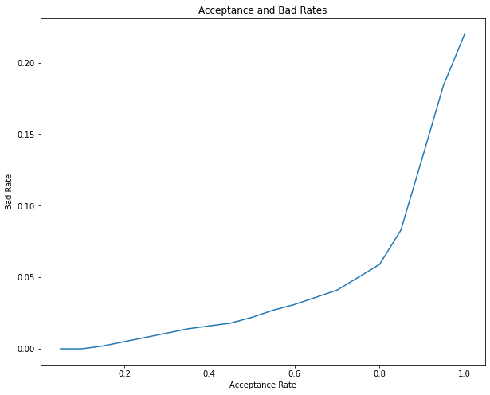

```python
# Plot the strategy curve
fig = plt.figure(figsize=(10,8))
plt.plot(strat_df['Acceptance Rate'], strat_df['Bad Rate'])
plt.xlabel('Acceptance Rate')
plt.ylabel('Bad Rate')
plt.title('Acceptance and Bad Rates')
plt.show()
```

### 5.10. Estimated value profiling

The strategy table, `strat_df`, can be used to maximize the estimated portfolio value and minimize expected loss. Extending this table and creating some plots can be very helpful to this end.

| Column | Description |
| --- | --- |
| Num Accepted Loans | The number of accepted loans based on the threshold |
| Avg Loan Amnt | The average loan amount of the entire test set |
| Estimated value | The estimated net value of non-defaults minus defaults |

```python
numAcceptLoan = []

for rate in accept_rates:
    numAcceptLoan.append(len(test_pred_df[test_pred_df['prob_default'] < np.quantile(test_pred_df['prob_default'], rate)]))

print(numAcceptLoan)
```

```
[11784, 11195, 10606, 10017, 9428, 8838, 8249, 7660, 7071, 6482, 5892, 5303, 4714, 4125, 3536, 2946, 2357, 1768, 1179, 590]
```

```python
strat_df['Avg Loan Amnt'] = round(np.mean(X_test['loan_amnt']),2)
strat_df['Num Accepted Loans'] = numAcceptLoan
strat_df['Estimated Value'] = ((strat_df['Num Accepted Loans'] * (1 - strat_df['Bad Rate']))
                               * strat_df['Avg Loan Amnt']) - (strat_df['Num Accepted Loans'] * strat_df['Bad Rate'] * strat_df['Avg Loan Amnt'])
strat_df['Estimated Value'] = strat_df['Estimated Value'].round(2)
strat_df
```

|  | Acceptance Rate | Threshold | Bad Rate | Avg Loan Amnt | Num Accepted Loans | Estimated Value |
| --- | --- | --- | --- | --- | --- | --- |
| 0 | 1.00 | 1.000 | 0.220 | 9534.21 | 11784 | 62916633.16 |
| 1 | 0.95 | 0.997 | 0.184 | 9534.21 | 11195 | 67456823.96 |
| 2 | 0.90 | 0.988 | 0.133 | 9534.21 | 10606 | 74221956.14 |
| 3 | 0.85 | 0.868 | 0.083 | 9534.21 | 10017 | 79650487.43 |
| 4 | 0.80 | 0.308 | 0.059 | 9534.21 | 9428 | 79281685.12 |
| 5 | 0.75 | 0.184 | 0.050 | 9534.21 | 8838 | 75837013.18 |
| 6 | 0.70 | 0.127 | 0.041 | 9534.21 | 8249 | 72198587.03 |
| 7 | 0.65 | 0.092 | 0.036 | 9534.21 | 7660 | 67773741.10 |
| 8 | 0.60 | 0.071 | 0.031 | 9534.21 | 7071 | 63236582.18 |
| 9 | 0.55 | 0.055 | 0.027 | 9534.21 | 6482 | 58463508.76 |
| 10 | 0.50 | 0.043 | 0.022 | 9534.21 | 5892 | 53703840.45 |
| 11 | 0.45 | 0.033 | 0.018 | 9534.21 | 5303 | 48739758.67 |
| 12 | 0.40 | 0.026 | 0.016 | 9534.21 | 4714 | 43506049.43 |
| 13 | 0.35 | 0.019 | 0.014 | 9534.21 | 4125 | 38227414.99 |
| 14 | 0.30 | 0.014 | 0.011 | 9534.21 | 3536 | 32971281.30 |
| 15 | 0.25 | 0.010 | 0.008 | 9534.21 | 2946 | 27638378.14 |
| 16 | 0.20 | 0.006 | 0.005 | 9534.21 | 2357 | 22247411.64 |
| 17 | 0.15 | 0.003 | 0.002 | 9534.21 | 1768 | 16789057.35 |
| 18 | 0.10 | 0.001 | 0.000 | 9534.21 | 1179 | 11240833.59 |
| 19 | 0.05 | 0.000 | 0.000 | 9534.21 | 590 | 5625183.90 |

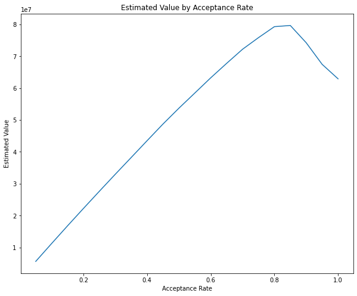

```python
# Create a line plot of estimated value
fig = plt.figure(figsize=(10,8))
plt.plot(strat_df['Acceptance Rate'],strat_df['Estimated Value'])
plt.title('Estimated Value by Acceptance Rate')
plt.xlabel('Acceptance Rate')
plt.ylabel('Estimated Value')
plt.show()
```

```python
# Print the row with the max estimated value
print(strat_df.loc[strat_df['Estimated Value'] == np.max(strat_df['Estimated Value'])])
```

```
   Acceptance Rate  Threshold  Bad Rate  Avg Loan Amnt  Num Accepted Loans  \
3             0.85      0.868     0.083        9534.21               10017

   Estimated Value
3      79650487.43
```

With our credit data and our estimated average loan value, we clearly see that the acceptance rate `0.85` has the highest potential estimated value. Normally, the allowable bad rate is set, but we can use analyses like this to explore other options.

### 5.11. Total expected loss

It's time to estimate the total expected loss given all your decisions. The data frame `test_pred_df` has the probability of default for each loan and that loan's value. Use these two values to calculate the expected loss for each loan. Then, you can sum those values and get the total expected loss.

[figure not shown]

For this exercise, you will assume that the exposure is the full value of the loan, and the loss given default is 100%. This means that a default on each the loan is a loss of the entire amount.

```python
test_pred_df['loss_given_default'] = 1.0

test_pred_df.drop('pred_loan_status', axis=1, inplace=True)
```

```python
# Print the first five rows of the data frame
print(test_pred_df.head())

# Calculate the bank's expected loss and assign it to a new column
test_pred_df['expected_loss'] = test_pred_df['prob_default'] * test_pred_df['loss_given_default'] * test_pred_df['loan_amnt']

# Calculate the total expected loss to two decimal places
tot_exp_loss = round(np.sum(test_pred_df['expected_loss']),2)

# Print the total expected loss
print('Total expected loss: ', '${:,.2f}'.format(tot_exp_loss))
```

```
   prob_default  true_loan_status  loan_amnt  loss_given_default
0      0.002017                 0       3000                 1.0
1      0.024879                 0      35000                 1.0
2      0.025256                 0      15000                 1.0
3      0.015450                 0      10800                 1.0
4      0.003830                 0      14000                 1.0
Total expected loss:  $27,232,567.99
```